# Projet

DE BADAR & VOEDZO

2023-11-16

Nous analysons un ensemble de données portant sur **250 clients** d’une banque. Ces données comprennent plusieurs variables clés pour chaque client : l’âge **(AGE)**, l’ancienneté de la relation avec la banque en mois **(RELAT)**, le montant total des avoirs en épargne financière **(HAVEF)**, le taux d’endettement **(ENDET)**, le nombre de paiements effectués par carte bancaire le mois précédant l’enquête **(ROCNB)**, le nombre total de cartes bancaires possédées **(NTCAS)**, et un score attribué par la banque **(SCORE)** qui classe les clients en cinq groupes distincts.

# Chargement du fichier

```r
data=read.table("clients.txt",header=TRUE)
data
```

```
##     AGE RELAT HAVEF ENDET ROCNB NTCAS SCORE
## 1    38   188     0     5    13     2     D
## 2    70   306   500    10     3     2     E
## 3    43    85     0    12    12     1     C
## 4    28    10     0     0     0     1     B
## 5    33     1     0     0     0     2     C
## 6    53     1     0     0     0     1     B
## 7    37     1     0     0     0     2     C
## 8    35   189     0    30    10     2     D
## 9    44   282   200     0    11     1     D
## 10   53    63     0    53    12     2     E
## 11   30    23     0     0     0     1     B
## 12   53     6     0     0     0     2     C
## 13   34     3     0     7     0     1     B
## 14   39     3     0     0     0     2     C
```

[output cut: 236 more lines]

# Normalisation des données pour l’ACP

```r
library(FactoMineR)
```

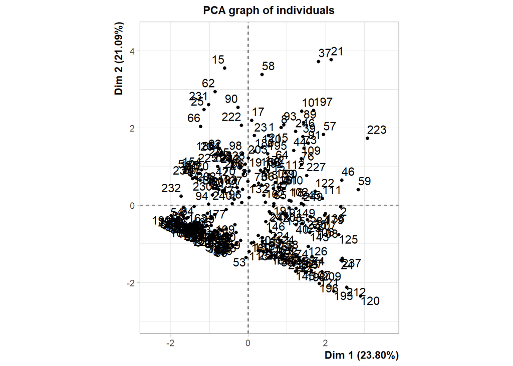

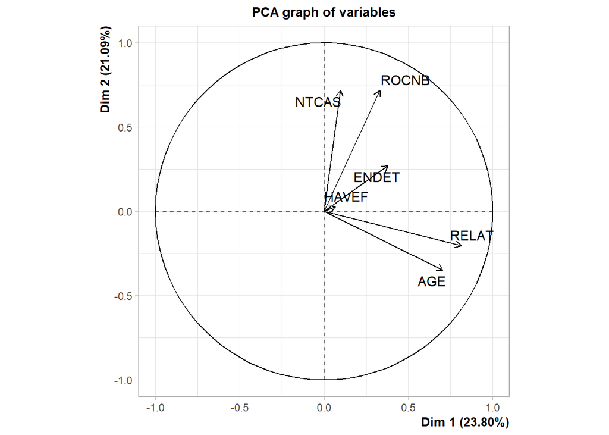

```r
result=PCA(data[,-7])
```

```r
result
```

```
## **Results for the Principal Component Analysis (PCA)**
## The analysis was performed on 250 individuals, described by 6 variables
## *The results are available in the following objects:
##
##    name               description
## 1  "$eig"             "eigenvalues"
## 2  "$var"             "results for the variables"
## 3  "$var$coord"       "coord. for the variables"
## 4  "$var$cor"         "correlations variables - dimensions"
## 5  "$var$cos2"        "cos2 for the variables"
## 6  "$var$contrib"     "contributions of the variables"
## 7  "$ind"             "results for the individuals"
## 8  "$ind$coord"       "coord. for the individuals"
## 9  "$ind$cos2"        "cos2 for the individuals"
## 10 "$ind$contrib"     "contributions of the individuals"
## 11 "$call"            "summary statistics"
## 12 "$call$centre"     "mean of the variables"
## 13 "$call$ecart.type" "standard error of the variables"
## 14 "$call$row.w"      "weights for the individuals"
## 15 "$call$col.w"      "weights for the variables"
```

# les valeurs propres et choix des axes

```r
result$eig
```

```
##        eigenvalue percentage of variance cumulative percentage of variance
## comp 1  1.4281339              23.802232                          23.80223
## comp 2  1.2655471              21.092451                          44.89468
## comp 3  1.0591593              17.652655                          62.54734
## comp 4  0.9471624              15.786041                          78.33338
## comp 5  0.7512240              12.520399                          90.85378
## comp 6  0.5487733               9.146222                         100.00000
```

Selection des axes pour l’ACP centréé réduites On selectionne le nombres d’axes qui nous permettent d’avoir un seuil qui depasse 80%. Pour les 4 premiers on a 78% (<80) donc on selectionnera cinq (5) axe pour l’ACP centré-réduite.

# Calcul des cosinus carre

```r
result$ind$cos2
```

```
##            Dim.1        Dim.2        Dim.3        Dim.4        Dim.5
## 1   6.189427e-02 7.267201e-01 2.078615e-02 7.538720e-02 2.544361e-02
## 2   6.461179e-01 2.268481e-04 1.020990e-01 5.789590e-02 1.420643e-01
## 3   3.628856e-05 1.920133e-01 3.316486e-02 1.150725e-01 2.835583e-01
## 4   9.382990e-01 2.737021e-02 1.001254e-04 3.126279e-02 1.621607e-03
## 5   4.837349e-01 1.306037e-01 1.077544e-01 2.168210e-02 2.181440e-01
## 6   2.887713e-01 2.424758e-01 4.847222e-02 3.848178e-03 9.488875e-02
## 7   4.197543e-01 1.130812e-01 1.367217e-01 3.472821e-02 2.786536e-01
## 8   1.057493e-01 5.848881e-01 1.024583e-02 1.899701e-01 1.348431e-02
## 9   3.114618e-01 1.508091e-03 2.977729e-02 4.768130e-02 5.413041e-01
## 10  1.182524e-01 3.681087e-01 1.451811e-02 3.255977e-01 1.126534e-01
## 11  9.219257e-01 4.692335e-02 6.733478e-06 2.806288e-02 1.419308e-03
## 12  1.137246e-01 3.139619e-02 2.387169e-01 1.054795e-01 4.894909e-01
## 13  7.820432e-01 3.442428e-02 9.891857e-04 1.484925e-01 1.385206e-02
## 14  3.797879e-01 1.031673e-01 1.529315e-01 4.307907e-02 3.105996e-01
```

[output cut: 236 more lines]

Somme par ligne

```r
somme_ligne= rowSums(result$ind$cos2)
somme_ligne
```

```
##         1         2         3         4         5         6         7         8
## 0.9102313 0.9484039 0.6238453 0.9986538 0.9619192 0.6784563 0.9829390 0.9043376
##         9        10        11        12        13        14        15        16
## 0.9317326 0.9391303 0.9983380 0.9788081 0.9798013 0.9895654 0.9999866 0.9780456
##        17        18        19        20        21        22        23        24
## 0.9668495 0.9963282 0.9783914 0.5578135 0.9748838 0.9617447 0.9639538 0.9869027
##        25        26        27        28        29        30        31        32
## 0.9129864 0.9747380 0.9794246 0.3047079 0.8955455 0.9710026 0.7168772 0.9801355
##        33        34        35        36        37        38        39        40
## 0.9900112 0.6090906 0.9970299 0.9455614 0.8773867 0.9943340 0.9682728 0.8860444
##        41        42        43        44        45        46        47        48
## 0.6053049 0.9325629 0.7753175 0.9899474 0.6799867 0.9997018 0.9592547 0.4773308
##        49        50        51        52        53        54        55        56
## 0.9997381 0.9929047 0.6175841 0.9880827 0.5155899 0.9955616 0.9635122 0.9876825
##        57        58        59        60        61        62        63        64
## 0.9993691 0.9952860 0.9997111 0.9992909 0.9999933 0.9910276 0.9148359 0.9785454
##        65        66        67        68        69        70        71        72
## 0.6700639 0.9973971 0.8601636 0.9854240 0.7869872 0.3421271 0.9994016 0.8603219
##        73        74        75        76        77        78        79        80
## 0.9997544 0.9886446 0.9815356 0.9531197 0.9982419 0.9110513 0.9110513 0.3601809
##        81        82        83        84        85        86        87        88
## 0.5626551 0.7168299 0.9560136 0.9929237 0.8861683 0.9426294 0.9989162 0.5549592
##        89        90        91        92        93        94        95        96
## 0.9989520 0.9994505 0.9795362 0.9779496 0.9470393 0.5036410 0.6123343 0.9313895
##        97        98        99       100       101       102       103       104
## 0.9971090 0.7749205 0.8360316 0.9233425 0.6372850 0.5392754 0.8854075 0.8820125
##       105       106       107       108       109       110       111       112
## 0.6170268 0.8740608 0.9529136 0.9158191 0.9774365 0.7340185 0.9148346 0.9991998
##       113       114       115       116       117       118       119       120
## 0.8798863 0.9828873 0.9818516 0.9994135 0.9120855 0.4442641 0.9808069 0.9769650
##       121       122       123       124       125       126       127       128
## 0.9929380 0.9990988 0.9631626 0.9996756 0.9999672 0.9820269 0.9788139 0.8180045
##       129       130       131       132       133       134       135       136
## 0.9884020 0.4954024 0.6787556 0.9282436 0.9569597 0.7158423 0.8074339 0.9940287
##       137       138       139       140       141       142       143       144
## 0.3791408 0.9890269 0.7245026 0.7733042 0.9977919 0.6588829 0.9554393 0.9826476
##       145       146       147       148       149       150       151       152
## 0.9111886 0.9861484 0.9035968 0.9954150 0.9672278 0.8584880 0.7434568 0.9918247
##       153       154       155       156       157       158       159       160
## 0.8801145 0.9903852 0.9004379 0.8971188 0.7421823 0.6153008 0.5005750 0.9980737
```

[output cut: 9 more lines]

```
## 0.8242432 0.9997638 0.7975848 0.8522951 0.9776605 0.9905384 0.6097205 0.6551482
##       201       202       203       204       205       206       207       208
## 0.9578205 0.8712223 0.5974297 0.7849964 0.9994685 0.5086888 0.9969345 0.8506842
##       209       210       211       212       213       214       215       216
## 0.9979683 0.8015248 0.8739874 0.9999761 0.8904613 0.5371276 0.7226198 0.9866211
##       217       218       219       220       221       222       223       224
## 0.6121105 0.7331494 0.9395634 0.9080628 0.9136865 0.9931876 0.9988064 0.9206840
##       225       226       227       228       229       230       231       232
## 0.9821576 0.9912701 0.5278433 0.8082800 0.9485122 0.9925534 0.9003197 0.9820996
##       233       234       235       236       237       238       239       240
## 0.9888378 0.9912824 0.9754159 0.8979326 0.9838478 0.9494212 0.4417925 0.8823749
##       241       242       243       244       245       246       247       248
## 0.6530093 0.7622025 0.9989573 0.8255467 0.9640533 0.9833923 0.1920047 0.8942260
##       249       250
## 0.6213466 0.9125588
```

Filtre

```r
unique (which(somme_ligne<0.6))
```

```
##  [1]  20  28  48  53  70  80  81  88  94 102 118 130 137 159 174 177 189 203 206
## [20] 214 227 239 247
```

Ces individus sont mal représentés et les autres bien représentés dans l’espace factoriel.

# Les contributions des individus et des variables sur les axes de l’acp

```r
result$ind$contrib
```

```
##            Dim.1        Dim.2        Dim.3        Dim.4        Dim.5
## 1   7.810475e-02 1.034868e+00 3.536785e-02 1.434396e-01 6.103869e-02
## 2   1.594260e+00 6.316450e-04 3.396848e-01 2.153969e-01 6.663949e-01
## 3   2.020027e-05 1.206172e-01 2.489277e-02 9.658364e-02 3.000747e-01
## 4   1.083357e+00 3.566146e-02 1.558771e-04 5.442552e-02 3.559389e-03
## 5   7.620906e-01 2.321910e-01 2.288980e-01 5.150447e-02 6.533440e-01
## 6   2.581725e-01 2.446329e-01 5.843276e-02 5.187469e-03 1.612761e-01
## 7   6.123610e-01 1.861630e-01 2.689412e-01 7.639048e-02 7.728166e-01
## 8   2.044701e-01 1.276192e+00 2.671205e-02 5.538374e-01 4.956564e-02
## 9   3.151967e-01 1.722245e-03 4.063215e-02 7.275611e-02 1.041401e+00
## 10  5.363378e-01 1.884063e+00 8.878637e-02 2.226662e+00 9.713426e-01
## 11  8.999062e-01 5.168696e-02 8.862340e-06 4.130266e-02 2.633767e-03
## 12  1.621595e-01 5.051908e-02 4.589641e-01 2.267777e-01 1.326881e+00
## 13  7.133803e-01 3.543609e-02 1.216679e-03 2.042394e-01 2.402172e-02
## 14  5.330233e-01 1.633946e-01 2.894074e-01 9.116241e-02 8.287154e-01
```

[output cut: 236 more lines]

Les vecteurs propre

```r
vecteurPropre=result$var$contrib
vecteurPropre
```

```
##           Dim.1     Dim.2      Dim.3      Dim.4     Dim.5
## AGE   34.831972  9.583572  5.0940471  6.9036951 11.228733
## RELAT 46.389372  3.296972  0.3324718  0.3974969  8.093096
## HAVEF  0.318616  0.056474 77.6443526  3.8295033 18.018167
## ENDET 10.158960  5.817913  0.2412655 76.8165290  6.387450
## ROCNB  7.635126 40.642770  4.2952577  2.6906020 29.700189
## NTCAS  0.665953 40.602299 12.3926052  9.3621738 26.572365
```

```r
pourcentagemoyen=100/6
```

Vérification de la contribution des individus Considérons 1.5 comme la contribution moyenne de chaque individu sur l’axe **Les individus qui contrubue significativement à l’axe 1**

```r
axe1=result$ind$coord[c( unique (which(result$ind$contrib[,1] > 1.5))),1]
axe1
```

```
##        2       24       46       59      120      125      212      223
## 2.385800 2.403531 2.420116 2.845970 2.907083 2.345160 2.544654 3.083336
##      237
## 2.432364
```

Tous les individus concernant cet axe ont des contributions positives On va chercher les variables qui contribue a l’axe et faire une représentation

```r
which(vecteurPropre[,1]>pourcentagemoyen)
```

```
##   AGE RELAT
##     1     2
```

```r
data[c(2,24,46,59,120,125,212,223,237),1]
```

```
## [1] 70 68 45 51 93 66 81 66 77
```

```r
data[c(2,24,46,59,120,125,212,223,237),2]
```

```
## [1] 306 325 210 245 317 337 339 314 309
```

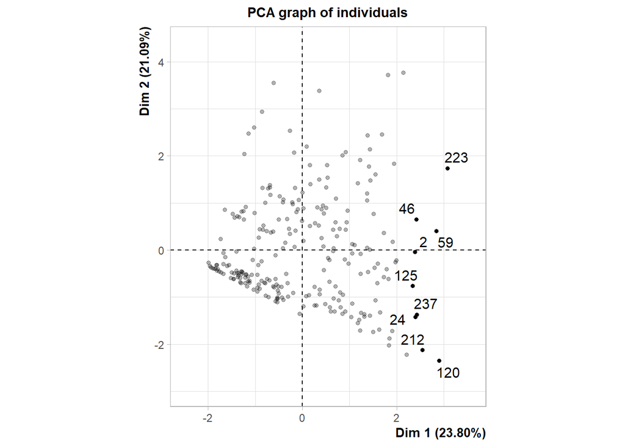

```r
plot(result,select = c(2,24,46,59,120,125,212,223,237))
```

**Interprétation** Cet axe représente principalement l’âge des clients (**AGE**) et l’ancienneté de la relation avec la banque (**RELAT**). Cet axe pourrait donc être interprété comme reflétant la maturité financière et la fidélité des clients. Les clients qui se situent positivement sur cet axe sont généralement plus âgés et ont une longue relation avec la banque.

**Les individus qui contribue significativement à l’axe 2**

```r
 axe2=result$ind$coord[c( unique (which(result$ind$contrib[,2] > 1.5))),2]
axe2
```

```
##        10        15        17        21        25        37        58        62
##  2.441501  3.553567  2.201520  3.770545  2.475603  3.723096  3.388971  2.941984
##        90       120       193       197       231
##  2.540657 -2.351535 -2.221422  2.457861  2.609805
```

```r
which(vecteurPropre[,2]>pourcentagemoyen)
```

```
## ROCNB NTCAS
##     5     6
```

```r
data[which(result$ind$contrib[,2] > 1.5),]
```

```
##     AGE RELAT HAVEF ENDET ROCNB NTCAS SCORE
## 10   53    63     0    53    12     2     E
## 15   38     1     0     0    15     3     D
## 17   33   153     0     0    16     2     D
## 21   47   227     0    30    18     3     E
## 25   32    28     0     3     3     3     C
## 37   36   275     0    24    17     3     E
## 58   50    55     0     0    17     3     D
## 62   38     3     0     0     9     3     D
## 90   31    90  1217     4    17     2     D
## 120  93   317     0     0     0     1     D
## 193  98   184     0     0     0     1     D
## 197  34    96     0    95    14     1     E
## 231  31    49     0     0     5     3     D
```

```r
colMeans(data[,-7])
```

```
##     AGE   RELAT   HAVEF   ENDET   ROCNB   NTCAS
##  44.928 132.536 723.820   5.756   5.012   1.252
```

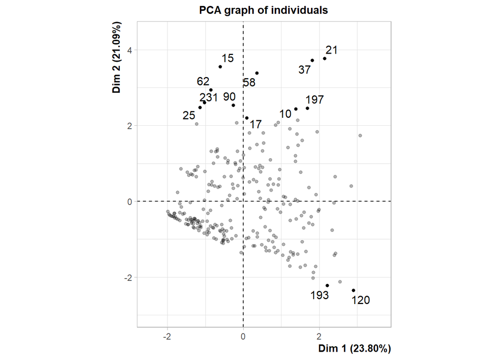

```r
plot(result,select = c(120,193,10,15,17,21,25,37,58,62,90,197,231),axes=c(1,2))
```

**Les individus qui contribue significativement à l’axe 3**

```r
axe3=result$ind$coord[c( unique (which(result$ind$contrib[,3] > 1.5))),3]
axe3
```

```
##       56      124      166      167      194      222      240
## 2.907604 4.307854 8.686722 3.502869 6.321111 6.573779 2.573848
```

**Caractéristiques communes et distinctes**

```r
which(vecteurPropre[,3]>pourcentagemoyen)
```

```
## HAVEF
##     3
```

```r
data[which(result$ind$contrib[,3] > 1.5),]
```

```
##     AGE RELAT HAVEF ENDET ROCNB NTCAS SCORE
## 56   40   165  9832     0    17     1     C
## 124  53   161 18341    10     1     1     B
## 166  37   120 33485     0    14     1     A
## 167  41   281 14294     0     0     1     B
## 194  53   133 26817     0     0     1     A
## 222  25    50 23381    19    19     1     A
## 240  27   184  9045     0     6     1     B
```

```r
colMeans(data[,-7])
```

```
##     AGE   RELAT   HAVEF   ENDET   ROCNB   NTCAS
##  44.928 132.536 723.820   5.756   5.012   1.252
```

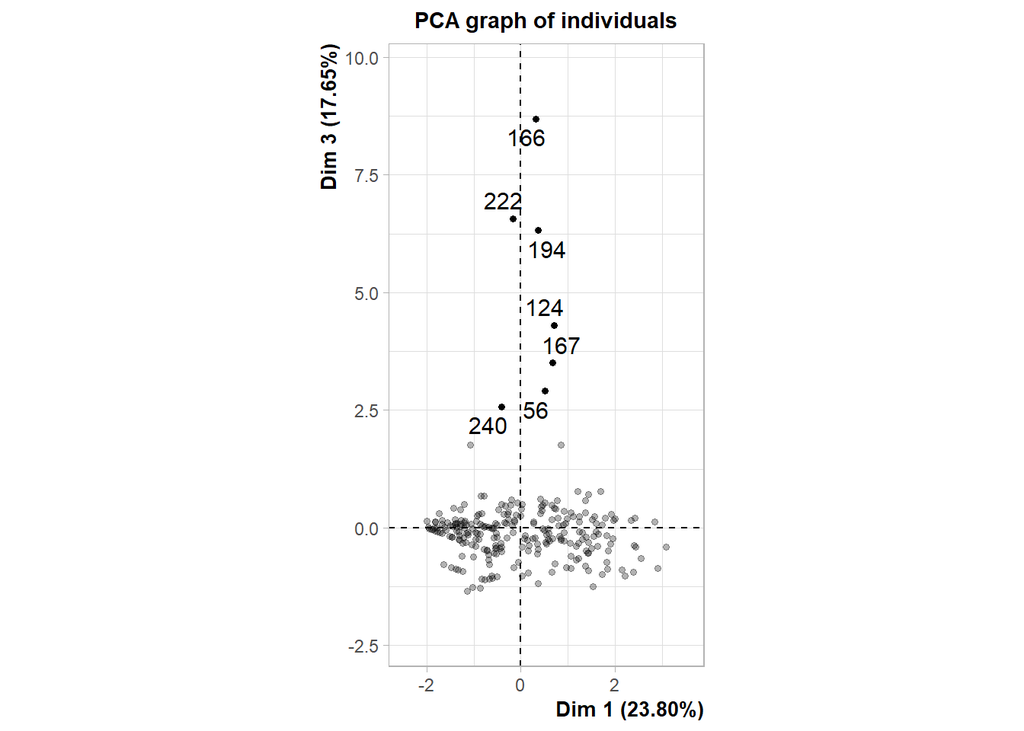

```r
plot(result,select = c(56,124,166,167,194,222,240), axes=c(1,3))
```

**Interprétation**

Dominé par le montant total des avoirs épargne financière (**HAVEF**). Cette dimension peut indiquer le niveau de richesse ou d’économies des clients. Les individus qui ont des scores élevés sur cet axe ont des montants d’épargne plus importants. Les individus en haut du graphique au centre ont leurs HAFEV les plus élévés des clients.

**Les individus qui contribue significativement à l’axe 4**

```r
axe4=result$ind$coord[c( unique (which(result$ind$contrib[,4] > 1.5))),4]
axe4
```

```
##        10        46        59        96       106       123       147       166
## -2.296198 -6.218809 -5.891358 -2.901118 -2.029661 -1.974831 -2.708493  2.087503
##       179       197       248
## -3.050413 -5.880191 -2.797865
```

**Caractéristiques communes et distinctes**

```r
which(vecteurPropre[,4]>pourcentagemoyen)
```

```
## ENDET
##     4
```

```r
data[which(result$ind$contrib[,4] > 1.5),]
```

```
##     AGE RELAT HAVEF ENDET ROCNB NTCAS SCORE
## 10   53    63     0    53    12     2     E
## 46   45   210     0    99     0     1     E
## 59   51   245     0    96     0     1     E
## 96   45    14     0    45     0     1     C
## 106  46   313     0    35     1     1     D
## 123  59   169     0    37     2     1     D
## 147  24   144     0    37     0     1     C
## 166  37   120 33485     0    14     1     A
## 179  46   294   200    51     1     1     D
## 197  34    96     0    95    14     1     E
## 248  56    48     0    47     0     1     D
```

```r
colMeans(data[,-7])
```

```
##     AGE   RELAT   HAVEF   ENDET   ROCNB   NTCAS
##  44.928 132.536 723.820   5.756   5.012   1.252
```

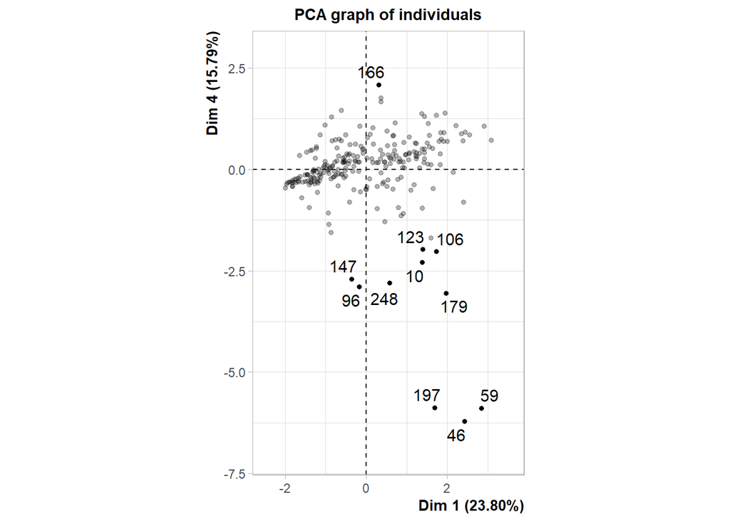

```r
plot(result,select = c( 10,46,59,96,106,123,147,166,179,197,248),axes=c(1,4))
```

**Les individus qui contribue significativement à l’axe 5**

```r
axe5=result$ind$coord[c( unique (which(result$ind$contrib[,5] > 1.5))),5]
axe5
```

```
##        25       124       166       186       192       194       225       243
##  1.844223  2.378139  2.603020 -1.838106 -1.872633  3.371561 -1.823628 -1.827039
```

**Caractéristiques communes et distinctes**

```r
which(vecteurPropre[,5]>pourcentagemoyen)
```

```
## HAVEF ROCNB NTCAS
##     3     5     6
```

```r
data[which(result$ind$contrib[,5] > 1.5),]
```

```
##     AGE RELAT HAVEF ENDET ROCNB NTCAS SCORE
## 25   32    28     0     3     3     3     C
## 124  53   161 18341    10     1     1     B
## 166  37   120 33485     0    14     1     A
## 186  25    84     0     0    17     1     C
## 192  36   198   200     0    17     1     C
## 194  53   133 26817     0     0     1     A
## 225  21   136     0     0    14     1     C
## 243  30   153     0     0    16     1     C
```

```r
colMeans(data[,-7])
```

```
##     AGE   RELAT   HAVEF   ENDET   ROCNB   NTCAS
##  44.928 132.536 723.820   5.756   5.012   1.252
```

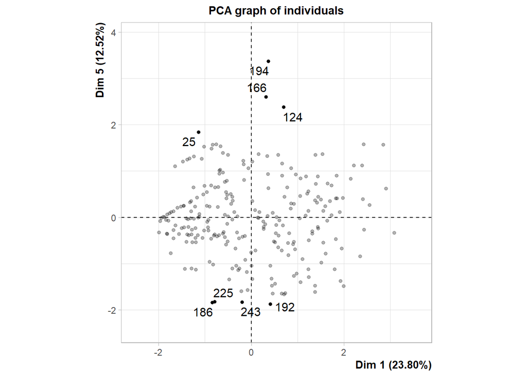

```r
plot(result,select = c(25,124,166,186,192,194,225,243),axes=c(1,5))
```

**Interprétation** L’axe 5 est une combinaison des variables, y compris **HAVEF**, **ROCNB**, et **NTCAS**. Cela suggère que cet axe représente une interaction entre la richesse, l’activité transactionnelle et l’utilisation des cartes. Les individus a gauche du graphique ont un **HAVEF** nulle.

# Classification

**Centralisation des données**

```r
donne=data[,1:6]
datacentre=scale(donne,center = TRUE, scale=FALSE)
datacentre
```

```
##            AGE    RELAT    HAVEF  ENDET  ROCNB  NTCAS
##   [1,]  -6.928   55.464  -723.82 -0.756  7.988  0.748
##   [2,]  25.072  173.464  -223.82  4.244 -2.012  0.748
##   [3,]  -1.928  -47.536  -723.82  6.244  6.988 -0.252
##   [4,] -16.928 -122.536  -723.82 -5.756 -5.012 -0.252
##   [5,] -11.928 -131.536  -723.82 -5.756 -5.012  0.748
##   [6,]   8.072 -131.536  -723.82 -5.756 -5.012 -0.252
##   [7,]  -7.928 -131.536  -723.82 -5.756 -5.012  0.748
##   [8,]  -9.928   56.464  -723.82 24.244  4.988  0.748
##   [9,]  -0.928  149.464  -523.82 -5.756  5.988 -0.252
##  [10,]   8.072  -69.536  -723.82 47.244  6.988  0.748
##  [11,] -14.928 -109.536  -723.82 -5.756 -5.012 -0.252
##  [12,]   8.072 -126.536  -723.82 -5.756 -5.012  0.748
##  [13,] -10.928 -129.536  -723.82  1.244 -5.012 -0.252
##  [14,]  -5.928 -129.536  -723.82 -5.756 -5.012  0.748
```

[output cut: 239 more lines]

**Classification hierarchique**

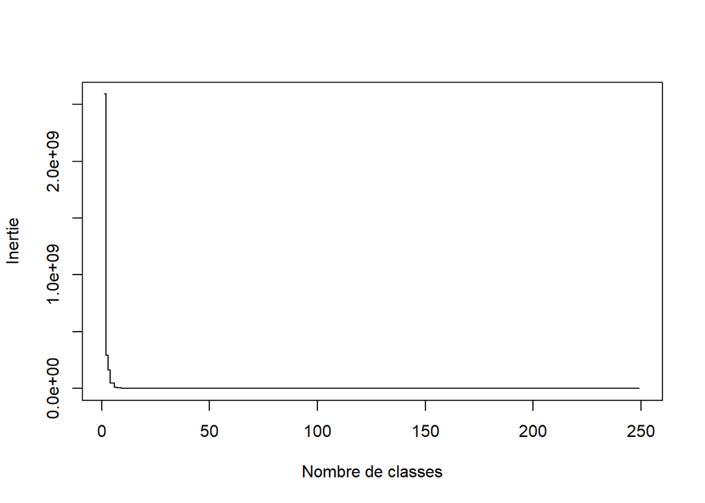

```r
#Calcule des distances entres les individus
 d=dist(datacentre)
#Effectuer la classification avec la fonction et inertie intra-classe
h=hclust(d^2/2,method="ward.D")
#Graphique dendogramme
inertie = sort(h$height, decreasing = TRUE)
plot(inertie[1:250], type = "s", xlab = "Nombre de classes", ylab = "Inertie")
```

# Choix du classement optimale

D’après le graphique, on remarque que la courbe arrete de varier au niveau d’un nombre de classe=5. On va donc diviser les individus en 5 groupes

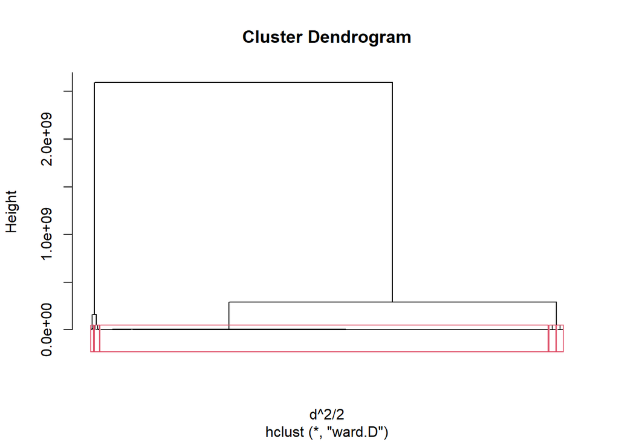

```r
plot(h, labels=F, hang=-1)
rect.hclust(h,k=5)
```

```r
groups <- cutree(h, k=5)
table(groups)
```

```
## groups
##   1   2   3   4   5
## 237   4   4   2   3
```

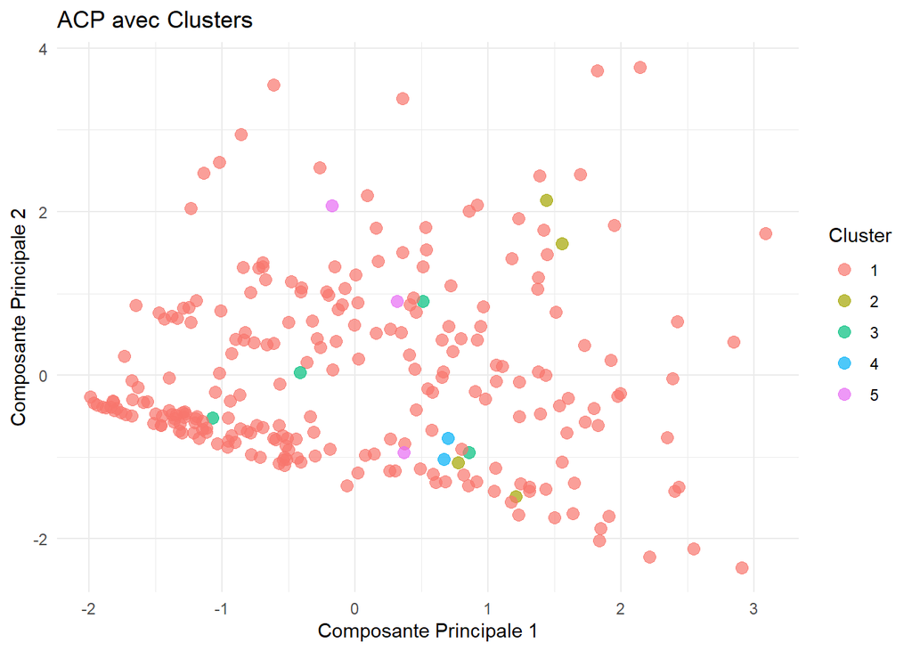

```r
library(ggplot2)
data_acp <- as.data.frame(result$ind$coord[, 1:2])  # utilisation des deux premières composantes principales
data_acp$cluster <- as.factor(groups)  # 'groups' mentioné plus haut

# Création du graphique avec les couleurs pour chaque groupe
ggplot(data_acp, aes(x=Dim.1, y=Dim.2, color=cluster)) +
  geom_point(alpha=0.7, size=3) +  # alpha pour la transparence si beaucoup de points se chevauchent
  theme_minimal() +
  labs(color='Cluster',
       x='Composante Principale 1',
       y='Composante Principale 2',
       title='ACP avec Clusters')
```

# Analyse des groupes

Groupe 1 (rouge) Étant le groupe le plus important, il occupe la majeure partie de l’espace sur le plan des deux premières composantes principales. Cela signifie que ce groupe est assez hétérogène et qu’il englobe une large variété de comportements parmi les clients. Les individus dans ce groupe n’ont pas de caractéristiques distinctives très fortes et peuvent représenter le “client moyen” de la banque.

# Résumé de l’analyse

cette analyse ACP et de clustering révèle que les comportements des clients sont influencés par une variété de facteurs, allant de la fidélité à la banque et la maturité financière, à l’activité transactionnelle et à la gestion de la dette. Les groupes identifiés montrent que, si certains clients suivent des tendances générales, d’autres présentent des comportements distincts ou extrêmes. Cela implique qu’il n’y a pas un comportement complètement homogène parmi les personnes étudiées.

En conclusion, face à cette multiplicité de profils et de besoins, il apparaît que les stratégies de service client uniformes seront moins efficaces. La banque pourrait donc tirer avantage de stratégies sur mesure, adaptées à chaque segment de clientèle. Une telle approche personnalisée permettrait non seulement de consolider la relation avec les clients existants mais aussi de maximiser la performance opérationnelle et financière de l’institution.